# Project Foundations for Data Science: FoodHub Data Analysis

**Marks: 40**

### Context

The number of restaurants in New York is increasing day by day. Lots of students and busy professionals rely on those restaurants due to their hectic lifestyles. Online food delivery service is a great option for them. It provides them with good food from their favorite restaurants. A food aggregator company FoodHub offers access to multiple restaurants through a single smartphone app.

The app allows the restaurants to receive a direct online order from a customer. The app assigns a delivery person from the company to pick up the order after it is confirmed by the restaurant. The delivery person then uses the map to reach the restaurant and waits for the food package. Once the food package is handed over to the delivery person, he/she confirms the pick-up in the app and travels to the customer's location to deliver the food. The delivery person confirms the drop-off in the app after delivering the food package to the customer. The customer can rate the order in the app. The food aggregator earns money by collecting a fixed margin of the delivery order from the restaurants.

### Objective

The food aggregator company has stored the data of the different orders made by the registered customers in their online portal. They want to analyze the data to get a fair idea about the demand of different restaurants which will help them in enhancing their customer experience. Suppose you are hired as a Data Scientist in this company and the Data Science team has shared some of the key questions that need to be answered. Perform the data analysis to find answers to these questions that will help the company to improve the business.

### Data Description

The data contains the different data related to a food order. The detailed data dictionary is given below.

### Data Dictionary

- order_id: Unique ID of the order
- customer_id: ID of the customer who ordered the food
- restaurant_name: Name of the restaurant
- cuisine_type: Cuisine ordered by the customer
- cost: Cost of the order
- day_of_the_week: Indicates whether the order is placed on a weekday or weekend (The weekday is from Monday to Friday and the weekend is Saturday and Sunday)
- rating: Rating given by the customer out of 5
- food_preparation_time: Time (in minutes) taken by the restaurant to prepare the food. This is calculated by taking the difference between the timestamps of the restaurant's order confirmation and the delivery person's pick-up confirmation.
- delivery_time: Time (in minutes) taken by the delivery person to deliver the food package. This is calculated by taking the difference between the timestamps of the delivery person's pick-up confirmation and drop-off information

### Let us start by importing the required libraries

```python
# import libraries for data manipulation
import numpy as np
import pandas as pd

# import libraries for data visualization
import matplotlib.pyplot as plt
import seaborn as sns
```

### Understanding the structure of the data

```python
# uncomment and run the following lines for Google Colab
from google.colab import drive
drive.mount('/content/drive')
```

```python
# read the data
df = pd.read_csv('/content/drive/MyDrive/DS Project 1/''foodhub_order.csv')
# returns the first 5 rows
df.head()
```

|  | order_id | customer_id | restaurant_name | cuisine_type | cost_of_the_order | day_of_the_week | rating | food_preparation_time | delivery_time |
| --- | --- | --- | --- | --- | --- | --- | --- | --- | --- |
| 0 | 1477147 | 337525 | Hangawi | Korean | 30.75 | Weekend | Not given | 25 | 20 |
| 1 | 1477685 | 358141 | Blue Ribbon Sushi Izakaya | Japanese | 12.08 | Weekend | Not given | 25 | 23 |
| 2 | 1477070 | 66393 | Cafe Habana | Mexican | 12.23 | Weekday | 5 | 23 | 28 |
| 3 | 1477334 | 106968 | Blue Ribbon Fried Chicken | American | 29.20 | Weekend | 3 | 25 | 15 |
| 4 | 1478249 | 76942 | Dirty Bird to Go | American | 11.59 | Weekday | 4 | 25 | 24 |

#### Observations:

The DataFrame has 9 columns as mentioned in the Data Dictionary. Data in each row corresponds to the order placed by a customer.

### **Question 1:** How many rows and columns are present in the data?

```python
df.shape #Prints the shape of the csv in the format of (rows, columns)
```

```
(1898, 9)
```

#### Observations: This is a larger dataset to search through, containing a number of entries. There are 1898 rows and 9 columns.

### **Question 2:** What are the datatypes of the different columns in the dataset? (The info() function can be used)

```python
# Use info() to print a concise summary of the DataFrame
df.info() #Gives all info on the types of data used for each column and the data.
```

```
<class 'pandas.core.frame.DataFrame'>
RangeIndex: 1898 entries, 0 to 1897
Data columns (total 9 columns):
 #   Column                 Non-Null Count  Dtype
---  ------                 --------------  -----
 0   order_id               1898 non-null   int64
 1   customer_id            1898 non-null   int64
 2   restaurant_name        1898 non-null   object
 3   cuisine_type           1898 non-null   object
 4   cost_of_the_order      1898 non-null   float64
 5   day_of_the_week        1898 non-null   object
 6   rating                 1898 non-null   object
 7   food_preparation_time  1898 non-null   int64
 8   delivery_time          1898 non-null   int64
dtypes: float64(1), int64(4), object(4)
memory usage: 133.6+ KB
```

Observations: There are 3 different datatypes included within the data. The datatypes are float, integer, and object. Float is cost of the order because of the decimal point for prices. The object types are for columns that include names or integers. The integers are either id numbers or food prep and delivery times, which are counted by whole number values.

### **Question 3:** Are there any missing values in the data? If yes, treat them using an appropriate method

```python
df.head() #This shows that rating has missing values, but the values are written down as not given.
```

|  | order_id | customer_id | restaurant_name | cuisine_type | cost_of_the_order | day_of_the_week | rating | food_preparation_time | delivery_time |
| --- | --- | --- | --- | --- | --- | --- | --- | --- | --- |
| 0 | 1477147 | 337525 | Hangawi | Korean | 30.75 | Weekend | Not given | 25 | 20 |
| 1 | 1477685 | 358141 | Blue Ribbon Sushi Izakaya | Japanese | 12.08 | Weekend | Not given | 25 | 23 |
| 2 | 1477070 | 66393 | Cafe Habana | Mexican | 12.23 | Weekday | 5 | 23 | 28 |
| 3 | 1477334 | 106968 | Blue Ribbon Fried Chicken | American | 29.20 | Weekend | 3 | 25 | 15 |
| 4 | 1478249 | 76942 | Dirty Bird to Go | American | 11.59 | Weekday | 4 | 25 | 24 |

```python
print(df['order_id'].value_counts())
print(df['customer_id'].value_counts())
print(df['restaurant_name'].value_counts())
print(df['cuisine_type'].value_counts())
print(df['cost_of_the_order'].value_counts())
print(df['day_of_the_week'].value_counts())
print(df['rating'].value_counts()) #This shows all of the entries for ratings and shows that the ratings entries are either 5,3,4, or 'Not given'.
print(df['food_preparation_time'].value_counts())
print(df['delivery_time'].value_counts())
```

```
order_id
1477147    1
1477697    1
1477555    1
1478028    1
1478308    1
          ..
1478087    1
1476775    1
1478421    1
1476774    1
1478056    1
Name: count, Length: 1898, dtype: int64
customer_id
52832     13
47440     10
83287      9
250494     8
259341     7
          ..
385426     1
254913     1
289597     1
74412      1
397537     1
Name: count, Length: 1200, dtype: int64
restaurant_name
Shake Shack                  219
The Meatball Shop            132
Blue Ribbon Sushi            119
Blue Ribbon Fried Chicken     96
Parm                          68
                            ...
Sushi Choshi                   1
Dos Caminos Soho               1
La Follia                      1
Philippe Chow                  1
'wichcraft                     1
Name: count, Length: 178, dtype: int64
cuisine_type
```

[output cut: 62 more lines]

```
30    133
25    120
19     90
16     90
20     88
15     87
22     85
18     83
21     81
17     78
23     77
32     59
33     49
31     41
Name: count, dtype: int64
```

```python
print(df['order_id'].unique())
print(df['customer_id'].unique())
print(df['restaurant_name'].unique())
print(df['cuisine_type'].unique())
print(df['cost_of_the_order'].unique())
print(df['day_of_the_week'].unique())
print(df['rating'].unique()) #This shows all of the entries for ratings and shows that the ratings entries are either 5,3,4, or 'Not given'.
print(df['food_preparation_time'].unique())
print(df['delivery_time'].unique())
#all columns unique values are printed below, showing which columns contain null values or not.
```

[output not shown]

[output cut: 28 more lines]

[output not shown]

```python
df.replace('Not given',np.nan) #Replaces the entries in rating that have 'Not given' with an undefined value (NaN) that treats the missing values accordingly.
```

|  | order_id | customer_id | restaurant_name | cuisine_type | cost_of_the_order | day_of_the_week | rating | food_preparation_time | delivery_time |
| --- | --- | --- | --- | --- | --- | --- | --- | --- | --- |
| 0 | 1477147 | 337525 | Hangawi | Korean | 30.75 | Weekend | NaN | 25 | 20 |
| 1 | 1477685 | 358141 | Blue Ribbon Sushi Izakaya | Japanese | 12.08 | Weekend | NaN | 25 | 23 |
| 2 | 1477070 | 66393 | Cafe Habana | Mexican | 12.23 | Weekday | 5 | 23 | 28 |
| 3 | 1477334 | 106968 | Blue Ribbon Fried Chicken | American | 29.20 | Weekend | 3 | 25 | 15 |
| 4 | 1478249 | 76942 | Dirty Bird to Go | American | 11.59 | Weekday | 4 | 25 | 24 |
| ... | ... | ... | ... | ... | ... | ... | ... | ... | ... |
| 1893 | 1476701 | 292602 | Chipotle Mexican Grill $1.99 Delivery | Mexican | 22.31 | Weekend | 5 | 31 | 17 |
| 1894 | 1477421 | 397537 | The Smile | American | 12.18 | Weekend | 5 | 31 | 19 |
| 1895 | 1477819 | 35309 | Blue Ribbon Sushi | Japanese | 25.22 | Weekday | NaN | 31 | 24 |
| 1896 | 1477513 | 64151 | Jack's Wife Freda | Mediterranean | 12.18 | Weekday | 5 | 23 | 31 |
| 1897 | 1478056 | 120353 | Blue Ribbon Sushi | Japanese | 19.45 | Weekend | NaN | 28 | 24 |

1898 rows × 9 columns

#### Observations: The only column that contains null values is ratings. Ratings contains null values and contains them under the object 'Not given'. We must replace this value in order to treat it correctly. This is done with the NumPy feature, 'np.nan'. If we enter a inplace=True for our function, we can make this change permanent.

### **Question 4:** Check the statistical summary of the data. What is the minimum, average, and maximum time it takes for food to be prepared once an order is placed?

```python
df.describe() #The code prints the statistical summary of the data
```

|  | order_id | customer_id | cost_of_the_order | food_preparation_time | delivery_time |
| --- | --- | --- | --- | --- | --- |
| count | 1.898000e+03 | 1898.000000 | 1898.000000 | 1898.000000 | 1898.000000 |
| mean | 1.477496e+06 | 171168.478398 | 16.498851 | 27.371970 | 24.161749 |
| std | 5.480497e+02 | 113698.139743 | 7.483812 | 4.632481 | 4.972637 |
| min | 1.476547e+06 | 1311.000000 | 4.470000 | 20.000000 | 15.000000 |
| 25% | 1.477021e+06 | 77787.750000 | 12.080000 | 23.000000 | 20.000000 |
| 50% | 1.477496e+06 | 128600.000000 | 14.140000 | 27.000000 | 25.000000 |
| 75% | 1.477970e+06 | 270525.000000 | 22.297500 | 31.000000 | 28.000000 |
| max | 1.478444e+06 | 405334.000000 | 35.410000 | 35.000000 | 33.000000 |

```python
df['food_preparation_time'].describe() #This is a specific statistical summary of the data for food prep time.
```

```
count    1898.000000
mean       27.371970
std         4.632481
min        20.000000
25%        23.000000
50%        27.000000
75%        31.000000
max        35.000000
Name: food_preparation_time, dtype: float64
```

#### Observations: For the food preparation time, we have a minimum of 20 minutes, we have a maximum of 35 minutes, and we have an average time of 27.37 minutes. Based off these calculations, we can say the data is very evenly distributed and doesnt skew very much. The mean is right in between the max and min values and close to the median.

### **Question 5:** How many orders are not rated?

```python
df['rating'].value_counts() #Gives the count of every unique entry into ratings. This in turn shows how many orders are not rated.
```

```
rating
Not given    736
5            588
4            386
3            188
Name: count, dtype: int64
```

#### Observations: Our code specificies every unique entry that is within the column rating. this shows us every entry or order, but also shows us which ones have a rating and which ones do not, by listing the unique entry 'Not given', which is the unrated orders. We can see that we have 736 orders that are not rated out of 1898.

### Exploratory Data Analysis (EDA)

### **Question 6:** Explore all the variables and provide observations on their distributions. (Generally, histograms, boxplots, countplots, etc. are used for univariate exploration)

```python
#imports needed to visualize our distributions.
import matplotlib.pyplot as plt
import seaborn as sns
```

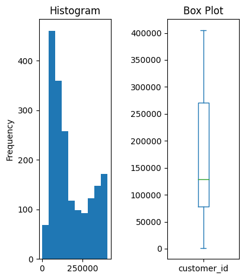

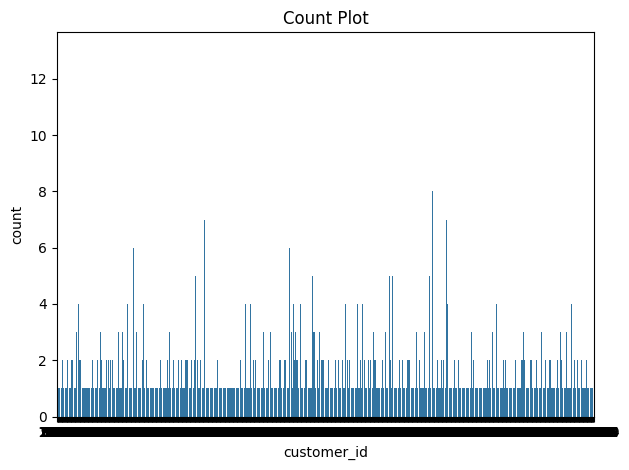

```python
# customer_id distribution

# Creates a subplot that contains the histogram and boxplot.
plt.subplot(1, 3, 1)
df['customer_id'].plot(kind='hist')
plt.title('Histogram')

plt.subplot(1, 3, 2)
df['customer_id'].plot(kind='box')
plt.title('Box Plot')

plt.tight_layout()
plt.show()

# Creates a countplot using seaborn and plt
sns.countplot(x='customer_id', data=df)
plt.title('Count Plot')

plt.tight_layout()
plt.show()
```

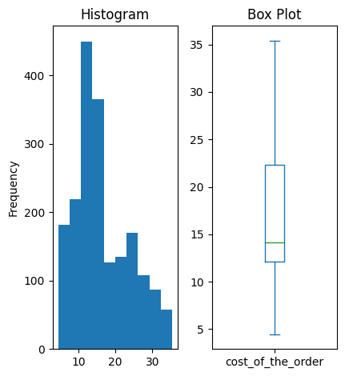

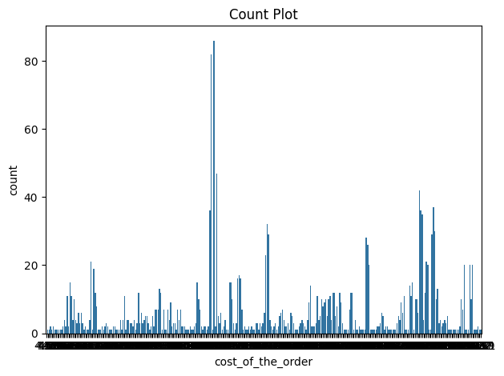

```python
# cost_of_the_order distribution

# Creates a subplot that contains the histogram and boxplot.
plt.subplot(1, 3, 1)
df['cost_of_the_order'].plot(kind='hist')
plt.title('Histogram')

plt.subplot(1, 3, 2)
df['cost_of_the_order'].plot(kind='box')
plt.title('Box Plot')

plt.tight_layout()
plt.show()

# Creates a countplot using seaborn and plt
sns.countplot(x='cost_of_the_order', data=df)
plt.title('Count Plot')

plt.tight_layout()
plt.show()
```

Observation: This is a continuous random variable due to the prices of the order, which are floats and can take any value within the range of values. According to the boxplot, the data is right-skewed. According to the histogram, the higher the price is for the most part, the lower the frequency seems to be. The countplot is very hard to analyze the data from due to the number of unique values or prices that are listed.

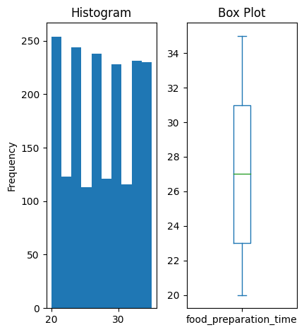

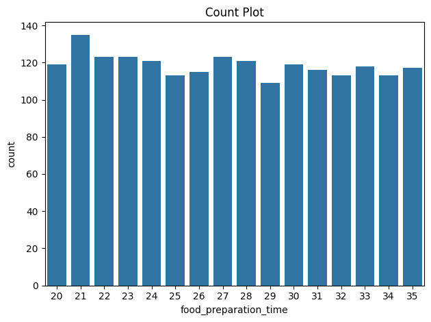

```python
#food_preparation_time distribution

# Creates a subplot that contains the histogram and boxplot.
plt.subplot(1, 3, 1)
df['food_preparation_time'].plot(kind='hist')
plt.title('Histogram')

plt.subplot(1, 3, 2)
df['food_preparation_time'].plot(kind='box')
plt.title('Box Plot')

plt.tight_layout()
plt.show()

# Creates a countplot using seaborn and plt
sns.countplot(x='food_preparation_time', data=df)
plt.title('Count Plot')

plt.tight_layout()
plt.show()
```

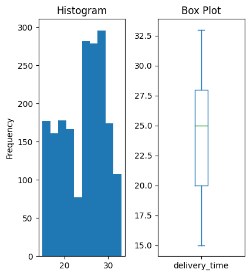

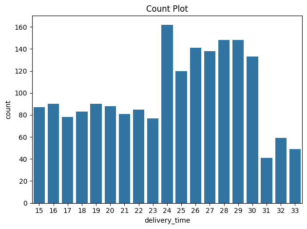

```python
#delivery_time distribution

# Creates a subplot that contains the histogram and boxplot.
plt.subplot(1, 3, 1)
df['delivery_time'].plot(kind='hist')
plt.title('Histogram')

plt.subplot(1, 3, 2)
df['delivery_time'].plot(kind='box')
plt.title('Box Plot')

plt.tight_layout()
plt.show()

# Creates a countplot using seaborn and plt
sns.countplot(x='delivery_time', data=df)
plt.title('Count Plot')

plt.tight_layout()
plt.show()
```

Observation: This is a discrete random variable due to all values being numerical and all whole numbers. According to the boxplot, the data seems to be left-skewed. You can also see this from the histogram due to the shape. The count plot shows that the delivery_time is most frequent between 24-30 minutes compared to the other times.

**Note:** restaurant_name, cuisine_type, rating, and day_of_the_week cannot be represented in a distribution on their own because they do not contain numerical values and order_id is unique values within each order and would all have a frequency of 1, so it can not be represented ina distribution by itself.

### **Question 7**: Which are the top 5 restaurants in terms of the number of orders received?

```python
df['restaurant_name'].value_counts().head() #Displays the top 5 restaurants in terms of number of orders received
```

```
restaurant_name
Shake Shack                  219
The Meatball Shop            132
Blue Ribbon Sushi            119
Blue Ribbon Fried Chicken     96
Parm                          68
Name: count, dtype: int64
```

### **Question 8**: Which is the most popular cuisine on weekends?

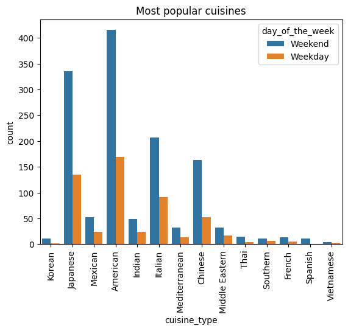

```python
sns.countplot(x='cuisine_type', hue='day_of_the_week', data=df) #creates a countplot of cuisine types and we split the columns based off weekend and weekdays.
plt.xticks(rotation=90) #rotates the x ticks labels to make more visible
plt.title('Most popular cuisines') #creates title for the graph
plt.show() #display graph
```

#### Observations: When we analyze the cuisine type frequency to find the most popular, we can use a countplot to find this frequency. We also want to find the most popular cuisine on the weekends. We do this by setting the hue to the day of the week. This splits the x counts into a group of weekend and weekday. As you can see, the most popular cuisines in general and on weekends (blue) are American, Italian, Chinese, and Japanese. The most popular cuisine on the weekend is American cuisine.

### **Question 9**: What percentage of the orders cost more than 20 dollars?

```python
over20_order = df[df['cost_of_the_order'] > 20] #Filters orders costing more than 20 dollars

percentov20 = over20_order.shape[0]/df['cost_of_the_order'].count()*100 #Calculates the percentage of orders costing more than 20 dollars

print('The percentage of orders costing more than 20 dollars is', round(percentov20, 2),'%') #Prints the percentage of orders costing more than 20 dollars
```

```
The percentage of orders costing more than 20 dollars is 29.24 %
```

#### Observations: We can observe that a good percentage of orders cost more than 20 dollars, 29.24 percent specifically.

### **Question 10**: What is the mean order delivery time?

```python
df['delivery_time'].mean() #Displays mean order delivery time
```

```
24.161749209694417
```

#### Observations: We can use .mean() to find the mean delivery time for an order. This mean delivery time is 24.16 minutes, which is also close to the most frequent delivery time, which is 24 minutes.

### **Question 11:** The company has decided to give 20% discount vouchers to the top 3 most frequent customers. Find the IDs of these customers and the number of orders they placed

```python
df['customer_id'].value_counts().head(3) #Displays the 3 most frequent customers
```

```
customer_id
52832    13
47440    10
83287     9
Name: count, dtype: int64
```

#### Observations: We can use .value_counts() to find the frequency of every customer_id that is used for orders. We can use .head() to display the top 3 most frequent customers. We can see that customers 52832, 47440, and 83287 are the IDs of top 3 most frequent customers. 52832 orders 13 times, 47440 ordered 10 times, and 83287 ordered 9 times.

### **Question 12**: Perform a multivariate analysis to explore relationships between the important variables in the dataset. (It is a good idea to explore relations between numerical variables as well as relations between numerical and categorical variables)

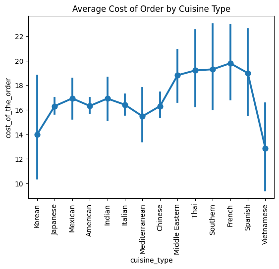

```python
sns.pointplot(x='cuisine_type', y='cost_of_the_order', data=df)
plt.xticks(rotation=90)
plt.title('Average Cost of Order by Cuisine Type')
plt.show()
```

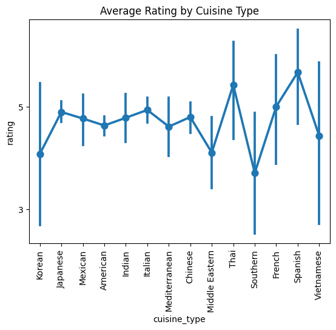

```python
sns.pointplot(x='cuisine_type', y='rating', data=df)
plt.xticks(rotation=90)
plt.title('Average Rating by Cuisine Type')
plt.show()
```

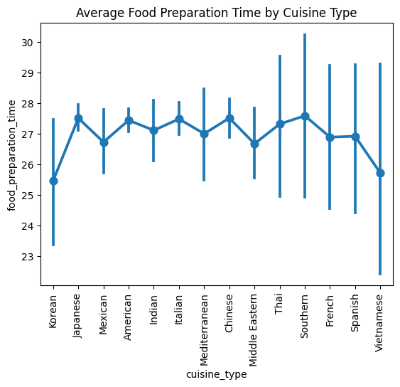

```python
sns.pointplot(x='cuisine_type', y='food_preparation_time', data=df)
plt.xticks(rotation=90)
plt.title('Average Food Preparation Time by Cuisine Type')
plt.show()
```

[figure not shown]

```python
sns.pointplot(x='day_of_the_week', y='rating', data=df)
plt.xticks(rotation=90)
plt.title('Average Rating by Day of the Week')
plt.show()
```

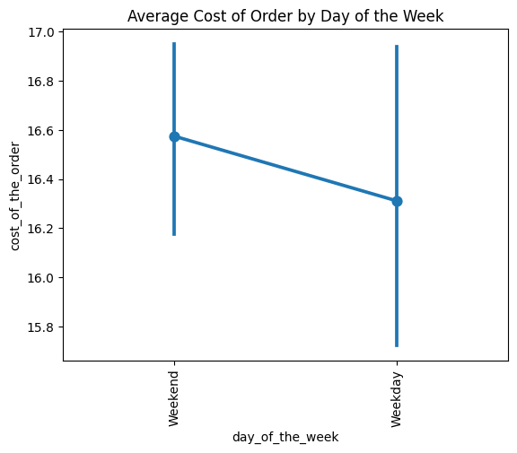

```python
sns.pointplot(x='day_of_the_week', y='cost_of_the_order', data=df)
plt.xticks(rotation=90)
plt.title('Average Cost of Order by Day of the Week')
plt.show()
```

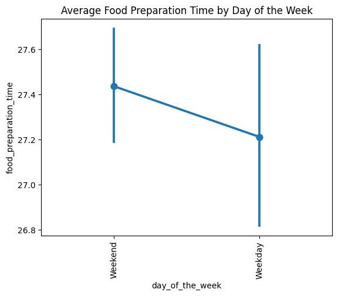

```python
sns.pointplot(x='day_of_the_week', y='food_preparation_time', data=df)
plt.xticks(rotation=90)
plt.title('Average Food Preparation Time by Day of the Week')
plt.show()
```

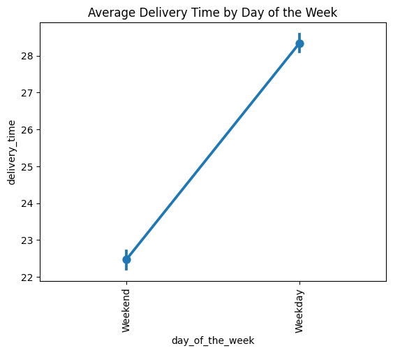

```python
sns.pointplot(x='day_of_the_week', y='delivery_time', data=df)
plt.xticks(rotation=90)
plt.title('Average Delivery Time by Day of the Week')
plt.show()
```

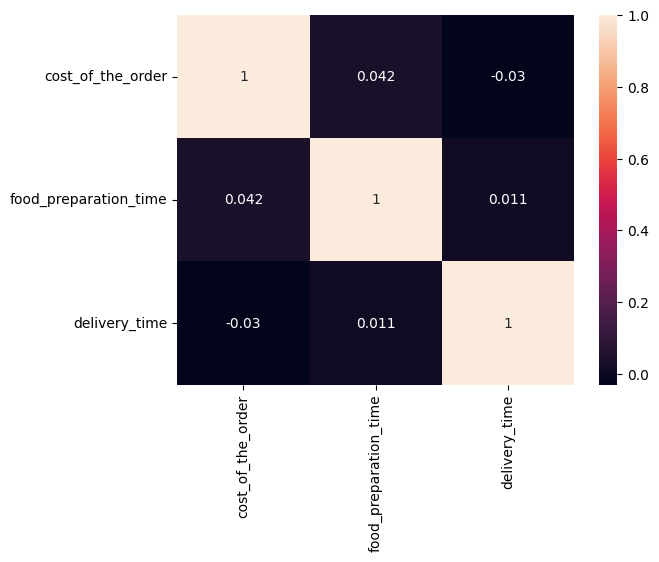

```python
heatmap = ['cost_of_the_order', 'food_preparation_time', 'delivery_time']
sns.heatmap(df[heatmap].corr(), annot=True)
plt.show()
```

```python
restcost = df.groupby(['restaurant_name'])['cost_of_the_order'].mean().sort_values(ascending = False).reset_index()
restcost.head(10)
```

|  | restaurant_name | cost_of_the_order |
| --- | --- | --- |
| 0 | Kambi Ramen House | 32.930000 |
| 1 | Emporio | 31.430000 |
| 2 | Bhatti Indian Grill | 31.115000 |
| 3 | Haru Gramercy Park | 29.830000 |
| 4 | Lucky Strike | 29.250000 |
| 5 | Il Bambino | 29.250000 |
| 6 | Sarabeth's | 29.133333 |
| 7 | Rohm Thai | 29.100000 |
| 8 | Klong | 29.050000 |
| 9 | 67 Burger | 29.050000 |

### **Question 13:** The company wants to provide a promotional offer in the advertisement of the restaurants. The condition to get the offer is that the restaurants must have a rating count of more than 50 and the average rating should be greater than 4. Find the restaurants fulfilling the criteria to get the promotional offer

```python
# We only want the restaurants with ratings.
df_rate = df[df['rating'] != 'Not given'].copy()

# Rating is an object, so we have to convert it to an integer in order to find the average.
df_rate['rating'] = df_rate['rating'].astype('int')

# We need the data to be grouped by restaurant name and the amount of ratings in order to find which ones have above 50 ratings.
rcount = df_rate.groupby(['restaurant_name'])['rating'].count().sort_values(ascending = False).reset_index()

#We can display the first 5 restaurants since the data is sorted, as you can see only the first 4  fufill the first part of the criteria
rcount.head()
```

|  | restaurant_name | rating |
| --- | --- | --- |
| 0 | Shake Shack | 133 |
| 1 | The Meatball Shop | 84 |
| 2 | Blue Ribbon Sushi | 73 |
| 3 | Blue Ribbon Fried Chicken | 64 |
| 4 | RedFarm Broadway | 41 |

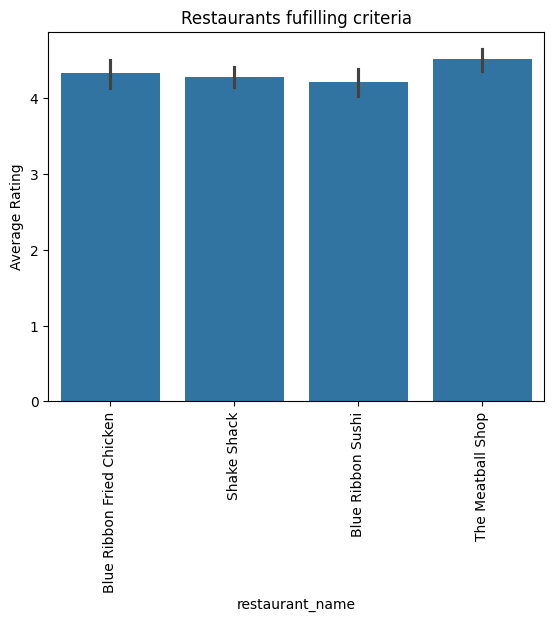

```python
# We can get the names of the restauraants with a count above 50 here to filter out the others.
rest_above_50 = rcount[rcount['rating']>50]['restaurant_name'] ## Complete the code to get the restaurant names having rating count more than 50

#Use the variable above to copy only the restaurants with above 50 count into the new dataframe.
rating_avg_4 = df_rate[df_rate['restaurant_name'].isin(rest_above_50)].copy()

# We can group the data by restaurant names and rating average now because we know every restaurant included is above 50 in count.
rating_avg_4.groupby(['restaurant_name'])['rating'].mean().sort_values(ascending = False).reset_index().dropna()

#We can now plot the restaurants fufilling the first requirement and look at the plot to see if the average is above 4.
sns.barplot(x='restaurant_name', y= 'rating', data=rating_avg_4)
plt.xticks(rotation=90)
plt.title('Restaurants fufilling criteria')
plt.ylabel('Average Rating')
plt.show()
```

#### Observations: The only restaurants that are above 50 ratings and an average rating above 4 are Blue Ribbon Fried Chicken, Shake Shack, Blue Ribbon Sushi, and The Meatball Shop.

### **Question 14:** The company charges the restaurant 25% on the orders having cost greater than 20 dollars and 15% on the orders having cost greater than 5 dollars. Find the net revenue generated by the company across all orders

```python
#Displays the total revenue that the company receives from orders.
def net_rev(ordercost): #function calculates the revenue per order.
    if ordercost > 20:
        return ordercost * 0.25
    elif ordercost > 5:
        return ordercost * 0.15
    else:
        return ordercost * 0
#Prints the total revenue they receive towards all orders.
print('The total revenue the company receives is $',round(sum(df['cost_of_the_order'].apply(net_rev)), 2))
```

```
The total revenue the company receives is $ 6166.3
```

```python
#Display the revenue that the company receives for 5 orders.
df['Revenue'] = round(df['cost_of_the_order'].apply(net_rev) , 2)
df.head()
```

|  | order_id | customer_id | restaurant_name | cuisine_type | cost_of_the_order | day_of_the_week | rating | food_preparation_time | delivery_time | Revenue |
| --- | --- | --- | --- | --- | --- | --- | --- | --- | --- | --- |
| 0 | 1477147 | 337525 | Hangawi | Korean | 30.75 | Weekend | Not given | 25 | 20 | 7.69 |
| 1 | 1477685 | 358141 | Blue Ribbon Sushi Izakaya | Japanese | 12.08 | Weekend | Not given | 25 | 23 | 1.81 |
| 2 | 1477070 | 66393 | Cafe Habana | Mexican | 12.23 | Weekday | 5 | 23 | 28 | 1.83 |
| 3 | 1477334 | 106968 | Blue Ribbon Fried Chicken | American | 29.20 | Weekend | 3 | 25 | 15 | 7.30 |
| 4 | 1478249 | 76942 | Dirty Bird to Go | American | 11.59 | Weekday | 4 | 25 | 24 | 1.74 |

#### Observations: We can see that in total the company received 6,166.30 from all orders that are included within the data. Individually the revenue that the orders bring in can vary. The orders bringing in 25% revenue seem to be around 7-8 dollars in revenue and the orders bring in 15% of revenue seem to bring in around 1-2 dollars of revenue.

### **Question 15:** The company wants to analyze the total time required to deliver the food. What percentage of orders take more than 60 minutes to get delivered from the time the order is placed? (The food has to be prepared and then delivered)

```python
df['order_time'] = df['food_preparation_time'] + df['delivery_time'] #Find the total time it takes to complete an order

over60 = df[df['order_time'] > 60] #Helps us select the orders taking more than 60 minutes to be delivered

percent = over60.shape[0]/df['order_time'].count()*100 #Helps us calculate the percentage of orders above 60 minutes

print('The percentage of orders that take more than 60 minutes is', round(percent, 2),'%') #Convert our calculation to a percentage
```

```
The percentage of orders that take more than 60 minutes is 10.54 %
```

#### Observations: The percentage of orders that take over 60 minutes is 10.54%. This is a smaller percentage of orders, but the company may want to lower this percentage in order to please customers.

### **Question 16:** The company wants to analyze the delivery time of the orders on weekdays and weekends. How does the mean delivery time vary during weekdays and weekends?

```python
print('Average delivery time for weekdays is', round(df[df['day_of_the_week'] == 'Weekday']['delivery_time'].mean()), 'minutes')
print('Average delivery time for weekends is', round(df[df['day_of_the_week'] == 'Weekend']['delivery_time'].mean()), 'minutes')
```

```
Average delivery time for weekdays is 28 minutes
Average delivery time for weekends is 22 minutes
```

#### Observations: Orders seem to take longer on average to deliver during the weekdays than they do during the weekend. The average delivery time for the weekend is 22 minutes vs 28 minutes for the weekdays, which is a 6 minute difference.

### Conclusion and Recommendations

### **Question 17:** What are your conclusions from the analysis? What recommendations would you like to share to help improve the business? (You can use cuisine type and feedback ratings to drive your business recommendations)

### Conclusions:

- The data set includes 1898 orders, 1200 unique customers who have ordered, 178 unique restaurants to order from, and 14 unique cuisine types.
- 736 orders include no rating, which is 38.8% of orders.
- The most popular cuisine on the weekend or weekdays is American.
- 29.24 percent of orders cost more than 20 dollars and 70.76 percent of orders are 20 dollars or under.
- The average time it takes to deliver an order is 24 minutes.
- The top 3 customers have ordered 13, 10, and 9 orders.
- French is the highest average costing cuisine type.
- Spanish is the highest average rating cuisine type.
- The weekend orders have a higher average cost than the weekday orders
- Weekend orders take 22 minutes on average to deliver and weekday orders take 28 minutes on average.
- There seems to be no correlation between order cost, food preparation time, and delivery time.
- The top 10 restaurants in highest average cost are Kami Ramen House, Emporio, Bhatti Indian Grill, Haru Gramercy Park, Lucky Strike, ll Bambino, Sarabeths, Rohm Thai, Klong, and 67 Burger.
- The top 5 restaurants with the highest number of ratings are Shake Shack, Meatball Shop, Blue Ribbon Sushi, Blue Ribbon Fried Chicken, and RedFarm Broadway.
- The company total revenue for all the orders included was 6,166.30 dollars.
- 10.54 percent of orders take more than 60 minutes to make.

### Recommendations:

**Application Reccomendations**

- Promote higher rated restaurants more like Shake Shack, Meatball Shop, Blue Ribbon Sushi, Blue Ribbon Fried Chicken, and RedFarm Broadway with a feature restaurants page within the app.
- There should be a categories section within the app to find what type of cuisine you are looking for. Within this categories section should have a featured cuisines area where high rated cuisines can be found and promoted from different restaurants.
- Drivers who work for the company should only be allowed to drive if they have a good rate of orders arriving on time. This promotes speed and lowering average delivery time. Once you have reached below a set percentage of orders delivered within time, you will be removed as a driver.
- Include a section that can track the analytics of restaurants and their average ratings, cost, and time to deliver and prepare food. Make this available for the restaurants, so they can see these analytics and improve themselves for deliveries through the app. Let companies interact with their own restaurant sections in order to be more involved and to care more about the analytics within the application.
- Use an Algorithm to show restaurants that customers frequent often or cuisines that the customer has spent more money on (For example, a customer spends majority of his money in the app on American cuisine, so promote high rated American cuisines to him).

**Promotion Reccomendations**

- A loyalty system should be introduced with reward points that you build up from ordering from a restaurant multiple times. This also promotes more reocurring orders.
- There should be a discount reward system introduced that can help promote more ratings being given. After a certain number of ratings given within the app after orders, a discount code can be given for a certain cuisine type of restaurant. This also could be just a discount on the overall order cost.
- (Promotion) Drivers should be rewarded with a bonus for completing more orders to provide incentive to drivers to finish orders at a faster rate. This can help bring down the total time it takes to make a delivery. This can be more emphasized during the week in order to lower the weekday delivery time.
- Lower rated restaurants and restaurants with the least orders should be promoted less within the app and give notification that they are.

```python
from google.colab import files
f = files.upload()

import subprocess
file0 = list(f.keys())[0]
_ = subprocess.run(["pip", "install", "nbconvert"])
_ = subprocess.run(["jupyter", "nbconvert", file0, "--to", "html"])

files.download(file0[:-5]+"html")
```